# Conversational Sequence Analysis

Yolanda Pan

2025-12-07

This following analysis investigates the structural and temporal dynamics of conversational turns to identify behavioral markers of good conversationalist. Specifically, this analysis incorporates:

1. **Basic Statistics for Sequence Types:** The average and standard deviation of *Question* and *Disclose* type, and their correlation.
2. **Micro-Structural Dynamics (Adjacency Pairs):** How do conversational turns chain together? Specifically, does the probability of a response depend on the type of antecedent (e.g., Question vs. Disclosure)?
3. **Macro-Temporal Dynamics (Escalation):** How does the distribution of disclosure evolve from the beginning to the end of an interaction?

## 1. Basic Information

### Exploration

| avg_Q | avg_D | sd_Q | sd_D |
| --- | --- | --- | --- |
| 26.29268 | 31.73171 | 16.11869 | 9.364893 |

On average, conversations contained slightly more disclosures than questions. The mean number of disclosures was about 32 per interaction, compared with about 26 questions. Variability was higher for questions (SD ≈ 16) than for disclosures (SD ≈ 9), indicating that some conversations were highly question-heavy while others had relatively few. Disclosures, by contrast, were more consistently present across conversations.

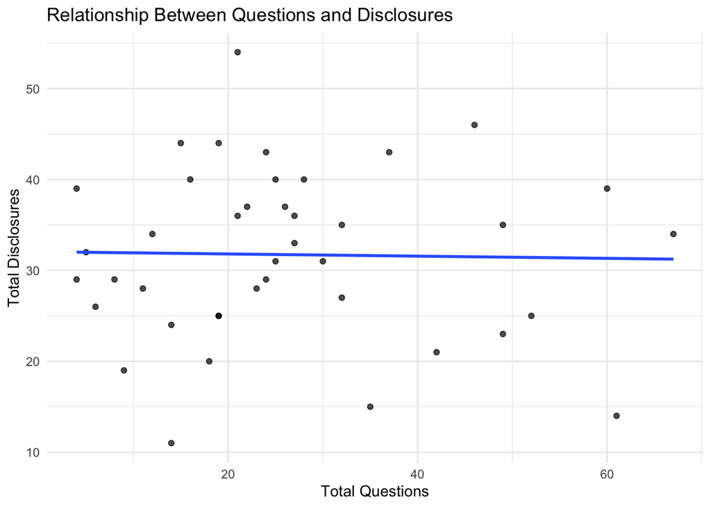

Across interactions, the total number of disclosures did not increase as a function of the total number of questions. The fitted regression line was flat, indicating that question frequency was not a reliable predictor of overall disclosure levels.

### Visualization

To establish a baseline understanding of conversational flow, I visualize the sequence duration and type for a random sample of dyads.

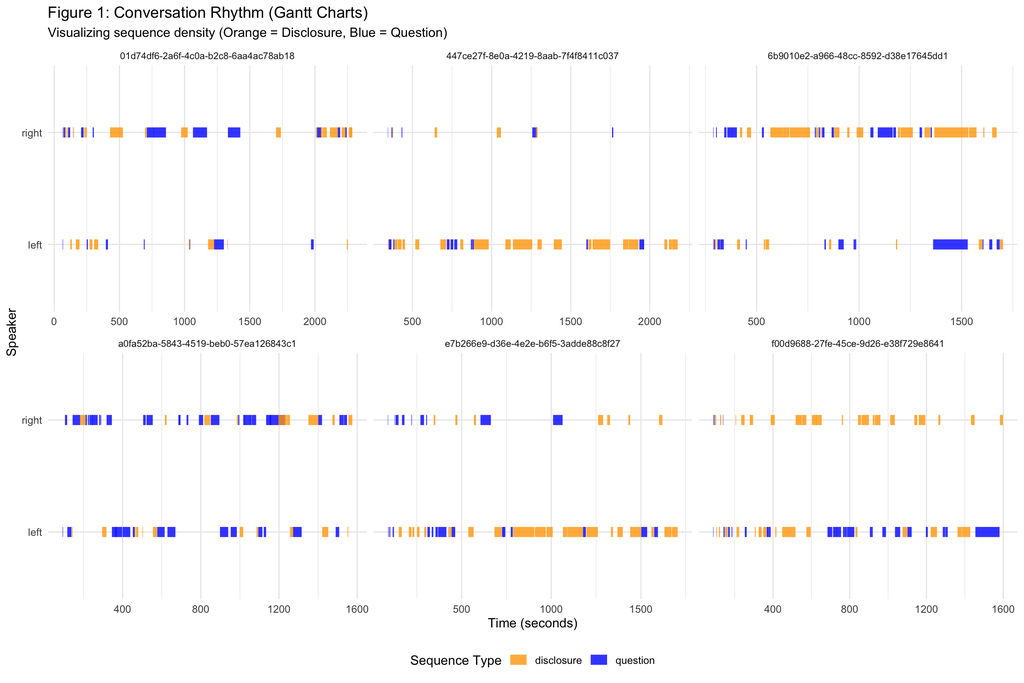

Figure 1 reveals distinct interaction styles, ranging from rapid, short exchanges to extended blocks of sustained disclosure. Some dyads are predominantly question-driven, others are disclosure-heavy, and still others maintain a more balanced pattern. In some cases, the interaction even resembles an interview, with one partner actively eliciting information from the other. This variance suggests that the rhythm of interaction—rather than content alone—may be a distinguishing feature of conversation quality.

## 2. Micro-Structural Analysis: Adjacency pairs

This section calculates the conditional probability of a specific response type given an antecedent. To isolate true interaction from monologue, I distinguish between transitions where the speaker holds the floor (“Same Speaker”) versus exchanges (“Switch Speaker”).

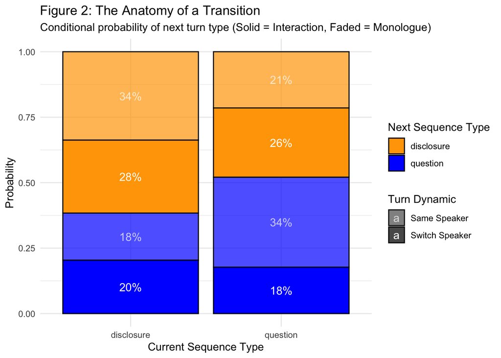

Figure 2 shows that when a question is followed by another question, this transition most often occurs within the same speaker. Surprisingly, 65% of all Question → Question sequences are self-generated rather than produced by the partner. This indicates that questions are frequently used to continue speaking, often through multi-part or elaborating inquiries, rather than immediately handing over the floor.

After a disclosure, the next turn is most likely to be another disclosure, regardless of whether the same speaker continues or the floor switches. This pattern shows that disclosure tends to sustain itself and create momentum. Once sharing begins, it is likely to continue, forming a stable rhythm of reciprocal or ongoing disclosure.

## 3. Temporal Analysis: The Escalation Arc

To understand how conversations evolve, I normalized interaction time (0-100%) and divided each conversation into 5 phases. This resolution captures the “warm-up” trajectory while smoothing sequence-level noise.

### 3.1 Global Temporal Patterns

First, I examine the aggregate trend across all dyads to determine if a “warm-up effect” exists.

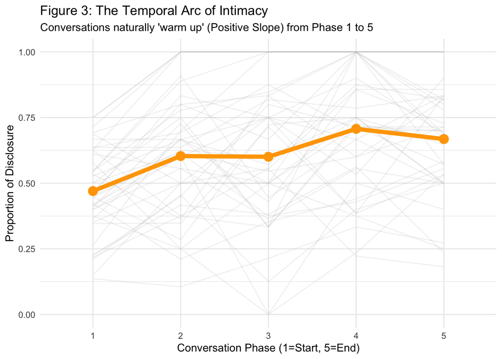

Figure 3 shows how the proportion of disclosure changes across five equal segments of each conversation. The average line (in orange) rises from about 0.48 in Phase 1 to a peak of roughly 0.70 in Phase 4, followed by a slight decline in Phase 5. Most individual conversations (gray lines) show some upward movement from early to later phases, even though trajectories vary.

The dominant pattern is a positive slope from the beginning of the interaction into the middle phases. Disclosure gradually becomes more frequent as conversations unfold. The last segment shows a small drop, but remains higher than the starting level.

This suggests that conversations naturally “warm up.” Early stages appear to involve less personal sharing, whereas middle and later phases tend to sustain longer or more frequent disclosures. The slight decline at the end may reflect wrap-up or time constraints, rather than a drop in intimacy per se.

One potential representation of each conversation is to label each trajectory (i.e., first up-middle down-final up) to see they show extinct differences in psychological outcomes.

### 3.2 Individual Speaker

To link temporal dynamics to “Good Conversationalist”, I disaggregate the analysis by speaker. I calculate an **Escalation Slope** for each participant, representing the rate at which they deepen the conversation over time.

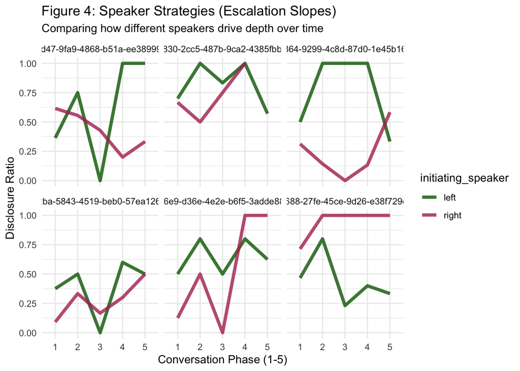

Figure 4 demonstrates that escalation strategies often differ within dyads. Future work could classify trajectory shapes (e.g., rising, convex, plateauing) and test whether alignment or synchrony predicts relational outcomes.

## 4. Hypothesis Proposal & Analysis Plan

Based on the structural finding that $D \rightarrow D$ represents a stable, high-intimacy state, and the temporal finding that conversations follow a distinct escalation arc, I propose two hypotheses to predict “Good Conversationalist” ratings.

**H1: The Reciprocity Hypothesis**

An individual’s Reciprocity Score, the probability of meeting a partner’s disclosure with a reciprocal disclosure, will be a significantly stronger predictor of partner ratings than their Responsiveness Score, the probability of self-disclosure after a partner’s question.

While answering questions ($Q \rightarrow D$) satisfies baseline politeness norms, it can establishes an asymmetric “Interview” dynamic. True connection is defined by the symmetric exchange of vulnerability ($D \rightarrow D$). Therefore, the ability to sustain a reciprocity loop represents a higher-order social skill than basic responsiveness.

```r
model_h1 <- lmer(partner_rating ~ reciprocity_score + responsiveness_score +
    (1 | interaction_id), data = speaker_level_data)

summary(model_h1)
```

To evaluate this hypothesis, we could fit a linear regression model in which the reciprocity and responsiveness scores of each participant served as predictors of their partner’s perceived good convsersationist rating.